# ANALYZE_casestudy_01_cyclisticbikeshare_2019to2020

Hongik Choi

2024-03-07

## Front Matter

```r
# Libraries
library(tidyverse)
library(janitor)
library(skimr)
library(lubridate)
library(purrr)
library(naniar)
library(scales)
# Data source
data_2019q1 <- read.csv("C:/Users/siyke/OneDrive/020_learn_from_courses_mooc/2000.Analytics/coursera/coursera_googlecert_data-analytics/google_da_capstone/casestudy_01/2019q1-2020q1/Divvy_Trips_2019_Q1.csv")
data_2020q1 <- read.csv("C:/Users/siyke/OneDrive/020_learn_from_courses_mooc/2000.Analytics/coursera/coursera_googlecert_data-analytics/google_da_capstone/casestudy_01/2019q1-2020q1/Divvy_Trips_2020_Q1.csv")
```

# Data exploration and data wrangling

```r
glimpse(data_2019q1)
```

```
## Rows: 365,069
## Columns: 12
## $ trip_id           <int> 21742443, 21742444, 21742445, 21742446, 21742447, 21…
## $ start_time        <chr> "2019-01-01 00:04:37", "2019-01-01 00:08:13", "2019-…
## $ end_time          <chr> "2019-01-01 00:11:07", "2019-01-01 00:15:34", "2019-…
## $ bikeid            <int> 2167, 4386, 1524, 252, 1170, 2437, 2708, 2796, 6205,…
## $ tripduration      <chr> "390.0", "441.0", "829.0", "1,783.0", "364.0", "216.…
## $ from_station_id   <int> 199, 44, 15, 123, 173, 98, 98, 211, 150, 268, 299, 2…
## $ from_station_name <chr> "Wabash Ave & Grand Ave", "State St & Randolph St", …
## $ to_station_id     <int> 84, 624, 644, 176, 35, 49, 49, 142, 148, 141, 295, 4…
## $ to_station_name   <chr> "Milwaukee Ave & Grand Ave", "Dearborn St & Van Bure…
## $ usertype          <chr> "Subscriber", "Subscriber", "Subscriber", "Subscribe…
## $ gender            <chr> "Male", "Female", "Female", "Male", "Male", "Female"…
## $ birthyear         <int> 1989, 1990, 1994, 1993, 1994, 1983, 1984, 1990, 1995…
```

- There are 12 columns.

```r
glimpse(data_2020q1)
```

```
## Rows: 426,887
## Columns: 13
## $ ride_id            <chr> "EACB19130B0CDA4A", "8FED874C809DC021", "789F3C21E4…
## $ rideable_type      <chr> "docked_bike", "docked_bike", "docked_bike", "docke…
## $ started_at         <chr> "2020-01-21 20:06:59", "2020-01-30 14:22:39", "2020…
## $ ended_at           <chr> "2020-01-21 20:14:30", "2020-01-30 14:26:22", "2020…
## $ start_station_name <chr> "Western Ave & Leland Ave", "Clark St & Montrose Av…
## $ start_station_id   <int> 239, 234, 296, 51, 66, 212, 96, 96, 212, 38, 117, 1…
## $ end_station_name   <chr> "Clark St & Leland Ave", "Southport Ave & Irving Pa…
## $ end_station_id     <int> 326, 318, 117, 24, 212, 96, 212, 212, 96, 100, 632,…
## $ start_lat          <dbl> 41.9665, 41.9616, 41.9401, 41.8846, 41.8856, 41.889…
## $ start_lng          <dbl> -87.6884, -87.6660, -87.6455, -87.6319, -87.6418, -…
## $ end_lat            <dbl> 41.9671, 41.9542, 41.9402, 41.8918, 41.8899, 41.884…
## $ end_lng            <dbl> -87.6674, -87.6644, -87.6530, -87.6206, -87.6343, -…
## $ member_casual      <chr> "member", "member", "member", "member", "member", "…
```

- There are 13 columns.

```r
skim(data_2019q1)
```

Data summary

| Name | data_2019q1 |
| --- | --- |
| Number of rows | 365069 |
| Number of columns | 12 |
| _______________________ |  |
| Column type frequency: |  |
| character | 7 |
| numeric | 5 |
| ________________________ |  |
| Group variables | None |

**Variable type: character**

| skim_variable | n_missing | complete_rate | min | max | empty | n_unique | whitespace |
| --- | --- | --- | --- | --- | --- | --- | --- |
| start_time | 0 | 1 | 19 | 19 | 0 | 343022 | 0 |
| end_time | 0 | 1 | 19 | 19 | 0 | 338367 | 0 |
| tripduration | 0 | 1 | 4 | 12 | 0 | 6666 | 0 |
| from_station_name | 0 | 1 | 10 | 43 | 0 | 594 | 0 |
| to_station_name | 0 | 1 | 10 | 43 | 0 | 600 | 0 |
| usertype | 0 | 1 | 8 | 10 | 0 | 2 | 0 |
| gender | 0 | 1 | 0 | 6 | 19711 | 3 | 0 |

**Variable type: numeric**

| skim_variable | n_missing | complete_rate | mean | sd | p0 | p25 | p50 | p75 | p100 | hist |
| --- | --- | --- | --- | --- | --- | --- | --- | --- | --- | --- |
| trip_id | 0 | 1.00 | 21960871.66 | 127175.00 | 21742443 | 21848765 | 21961829 | 22071823 | 22178528 | ▇▇▇▇▇ |
| bikeid | 0 | 1.00 | 3429.48 | 1923.32 | 1 | 1777 | 3489 | 5157 | 6471 | ▆▆▆▆▇ |
| from_station_id | 0 | 1.00 | 198.09 | 153.49 | 2 | 76 | 170 | 287 | 665 | ▇▅▃▁▁ |
| to_station_id | 0 | 1.00 | 198.58 | 154.47 | 2 | 76 | 168 | 287 | 665 | ▇▅▃▁▁ |
| birthyear | 18023 | 0.95 | 1981.67 | 11.25 | 1900 | 1975 | 1985 | 1990 | 2003 | ▁▁▁▅▇ |

- ‘gender’ column has 19,711 values as empty. That accounts for 5.3992533% of the entire rows of data.
- ‘birthyear’ column as 18,023 missing values. That accounts for 4.9368749% of the entire rows of data.

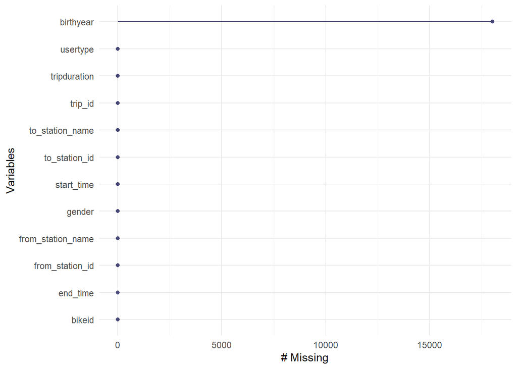

```r
gg_miss_var(data_2019q1)
```

```r
skim(data_2020q1)
```

Data summary

| Name | data_2020q1 |
| --- | --- |
| Number of rows | 426887 |
| Number of columns | 13 |
| _______________________ |  |
| Column type frequency: |  |
| character | 7 |
| numeric | 6 |
| ________________________ |  |
| Group variables | None |

**Variable type: character**

| skim_variable | n_missing | complete_rate | min | max | empty | n_unique | whitespace |
| --- | --- | --- | --- | --- | --- | --- | --- |
| ride_id | 0 | 1 | 16 | 16 | 0 | 426887 | 0 |
| rideable_type | 0 | 1 | 11 | 11 | 0 | 1 | 0 |
| started_at | 0 | 1 | 19 | 19 | 0 | 399265 | 0 |
| ended_at | 0 | 1 | 19 | 19 | 0 | 399532 | 0 |
| start_station_name | 0 | 1 | 5 | 43 | 0 | 607 | 0 |
| end_station_name | 0 | 1 | 0 | 43 | 1 | 603 | 0 |
| member_casual | 0 | 1 | 6 | 6 | 0 | 2 | 0 |

**Variable type: numeric**

| skim_variable | n_missing | complete_rate | mean | sd | p0 | p25 | p50 | p75 | p100 | hist |
| --- | --- | --- | --- | --- | --- | --- | --- | --- | --- | --- |
| start_station_id | 0 | 1 | 209.80 | 163.22 | 2.00 | 77.00 | 176.00 | 298.00 | 675.00 | ▇▆▃▁▁ |
| end_station_id | 1 | 1 | 209.34 | 163.20 | 2.00 | 77.00 | 175.00 | 297.00 | 675.00 | ▇▅▃▁▁ |
| start_lat | 0 | 1 | 41.90 | 0.04 | 41.74 | 41.88 | 41.89 | 41.92 | 42.06 | ▁▁▇▂▁ |
| start_lng | 0 | 1 | -87.64 | 0.02 | -87.77 | -87.66 | -87.64 | -87.63 | -87.55 | ▁▁▇▇▁ |
| end_lat | 1 | 1 | 41.90 | 0.04 | 41.74 | 41.88 | 41.89 | 41.92 | 42.06 | ▁▁▇▂▁ |
| end_lng | 1 | 1 | -87.64 | 0.02 | -87.77 | -87.66 | -87.64 | -87.63 | -87.55 | ▁▁▇▇▁ |

- Only the columns ‘end_station_id’, ‘end_lat’, and ‘end_lng’ have 1 missing rows each.

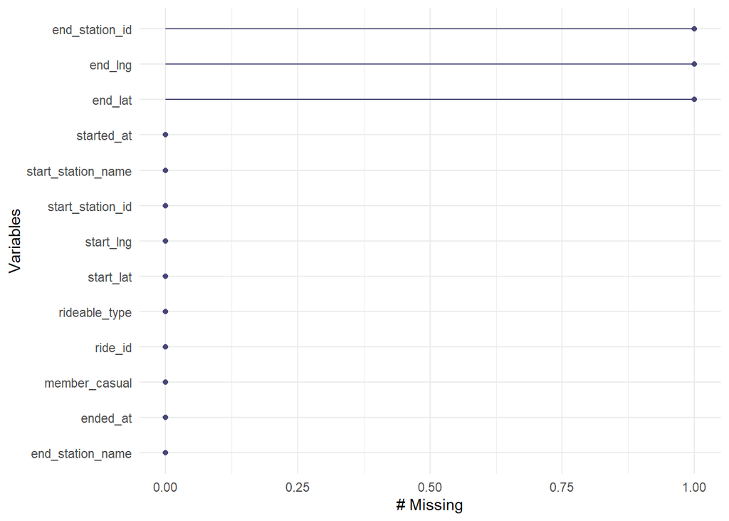

```r
gg_miss_var(data_2020q1)
```

## Empty or missing values are removed

```r
# Empty or missing values are removed because they only represent a small amount of the entire dataset. This is only true for 2020 file. 2019 file's columns containing missing values ('gender', 'birthyear') will be removed because 2020q1 file does not contain that information.
data_2020q1_cleaned <- data_2020q1 %>%
  filter(!is.na(end_station_id) & !is.na(end_lat) & !is.na(end_lng))
```

## Check that the removal is complete and successful

```r
skim(data_2020q1_cleaned)
```

Data summary

| Name | data_2020q1_cleaned |
| --- | --- |
| Number of rows | 426886 |
| Number of columns | 13 |
| _______________________ |  |
| Column type frequency: |  |
| character | 7 |
| numeric | 6 |
| ________________________ |  |
| Group variables | None |

**Variable type: character**

| skim_variable | n_missing | complete_rate | min | max | empty | n_unique | whitespace |
| --- | --- | --- | --- | --- | --- | --- | --- |
| ride_id | 0 | 1 | 16 | 16 | 0 | 426886 | 0 |
| rideable_type | 0 | 1 | 11 | 11 | 0 | 1 | 0 |
| started_at | 0 | 1 | 19 | 19 | 0 | 399264 | 0 |
| ended_at | 0 | 1 | 19 | 19 | 0 | 399531 | 0 |
| start_station_name | 0 | 1 | 5 | 43 | 0 | 607 | 0 |
| end_station_name | 0 | 1 | 5 | 43 | 0 | 602 | 0 |
| member_casual | 0 | 1 | 6 | 6 | 0 | 2 | 0 |

**Variable type: numeric**

| skim_variable | n_missing | complete_rate | mean | sd | p0 | p25 | p50 | p75 | p100 | hist |
| --- | --- | --- | --- | --- | --- | --- | --- | --- | --- | --- |
| start_station_id | 0 | 1 | 209.80 | 163.22 | 2.00 | 77.00 | 176.00 | 298.00 | 675.00 | ▇▆▃▁▁ |
| end_station_id | 0 | 1 | 209.34 | 163.20 | 2.00 | 77.00 | 175.00 | 297.00 | 675.00 | ▇▅▃▁▁ |
| start_lat | 0 | 1 | 41.90 | 0.04 | 41.74 | 41.88 | 41.89 | 41.92 | 42.06 | ▁▁▇▂▁ |
| start_lng | 0 | 1 | -87.64 | 0.02 | -87.77 | -87.66 | -87.64 | -87.63 | -87.55 | ▁▁▇▇▁ |
| end_lat | 0 | 1 | 41.90 | 0.04 | 41.74 | 41.88 | 41.89 | 41.92 | 42.06 | ▁▁▇▂▁ |
| end_lng | 0 | 1 | -87.64 | 0.02 | -87.77 | -87.66 | -87.64 | -87.63 | -87.55 | ▁▁▇▇▁ |

## Columns are modified

### Unused columns removed: Removed for 2019

```r
data_2019q1_cleaned <- data_2019q1 %>%
  select(-trip_id, -bikeid, -gender, -birthyear)

# Check for any missing or empty values
skim(data_2019q1_cleaned)
```

Data summary

| Name | data_2019q1_cleaned |
| --- | --- |
| Number of rows | 365069 |
| Number of columns | 8 |
| _______________________ |  |
| Column type frequency: |  |
| character | 6 |
| numeric | 2 |
| ________________________ |  |
| Group variables | None |

**Variable type: character**

| skim_variable | n_missing | complete_rate | min | max | empty | n_unique | whitespace |
| --- | --- | --- | --- | --- | --- | --- | --- |
| start_time | 0 | 1 | 19 | 19 | 0 | 343022 | 0 |
| end_time | 0 | 1 | 19 | 19 | 0 | 338367 | 0 |
| tripduration | 0 | 1 | 4 | 12 | 0 | 6666 | 0 |
| from_station_name | 0 | 1 | 10 | 43 | 0 | 594 | 0 |
| to_station_name | 0 | 1 | 10 | 43 | 0 | 600 | 0 |
| usertype | 0 | 1 | 8 | 10 | 0 | 2 | 0 |

**Variable type: numeric**

| skim_variable | n_missing | complete_rate | mean | sd | p0 | p25 | p50 | p75 | p100 | hist |
| --- | --- | --- | --- | --- | --- | --- | --- | --- | --- | --- |
| from_station_id | 0 | 1 | 198.09 | 153.49 | 2 | 76 | 170 | 287 | 665 | ▇▅▃▁▁ |
| to_station_id | 0 | 1 | 198.58 | 154.47 | 2 | 76 | 168 | 287 | 665 | ▇▅▃▁▁ |

### Unused columns removedRemoved for 2020

```r
data_2020q1_cleaned <- data_2020q1_cleaned %>%
  select(-ride_id, -rideable_type, -start_lat, -start_lng, -end_lat, -end_lng)
```

## Columns are wrangeld.

### Column names are unified.

```r
data_2020q1_cleaned <- data_2020q1_cleaned %>%
  rename(
    start_time = started_at,
    end_time = ended_at,
    from_station_id = start_station_id,
    from_station_name = start_station_name,
    to_station_id = end_station_id,
    to_station_name = end_station_name,
    usertype = member_casual
  )
```

### Columns’ data types are adjusted.

```r
# Turn star_time and end_time into ymd_hms format using lubridate.
data_2019q1_cleaned <- data_2019q1_cleaned %>%
  mutate(
    start_time = ymd_hms(start_time),
    end_time = ymd_hms(end_time)
  )

data_2020q1_cleaned <- data_2020q1_cleaned %>%
  mutate(
    start_time = ymd_hms(start_time),
    end_time = ymd_hms(end_time)
  )

# Turn 'from_station_id' and 'to_station_name' from INT to CHR
data_2019q1_cleaned <- data_2019q1_cleaned %>%
  mutate(
    from_station_id = as.character(from_station_id),
    to_station_id = as.character(to_station_id)
  )

data_2020q1_cleaned <- data_2020q1_cleaned %>%
  mutate(
    from_station_id = as.character(from_station_id),
    to_station_id = as.character(to_station_id)
  )
```

### ‘tripduration’ column is created for data_2020q1_cleaned

```r
data_2020q1_cleaned <- data_2020q1_cleaned %>%
  mutate(tripduration = as.numeric(difftime(end_time, start_time, units = "secs")))

data_2019q1_cleaned <- data_2019q1_cleaned %>%
  mutate(tripduration = as.numeric(difftime(end_time, start_time, units = "secs")))
```

### Rearrange columns so that the orders are consistent across the dataframes

```r
data_2020q1_cleaned <- data_2020q1_cleaned %>%
  select(start_time, end_time, tripduration, from_station_id, from_station_name, to_station_id, to_station_name, usertype)
```

## Values in the columns are consistently applied

```r
# 2019 file's 'usertype' column contains "Subscriber" and "Customer" as the values while 2020 file's 'usertype' column contains "member" and "casual".
data_2019q1_cleaned <- data_2019q1_cleaned %>%
  mutate(usertype = recode(usertype,
                           "Subscriber" = "Member",
                           "Customer" = "Casual"))

data_2020q1_cleaned <- data_2020q1_cleaned %>%
  mutate(usertype = recode(usertype,
                           "member" = "Member",
                           "casual" = "Casual"))
```

## Check that the Station ID and Station Names are consistenly applied

### Check that the usage of station_id <-> station_name is consistent among froms

```r
# Four columns have to be checked: from_station_id, from_station_name, to_station_id, to_station_name

# 1. Check that the usage of station_id <-> station_name is consistent among froms
temp_unique_from_2019 <- data_2019q1_cleaned %>%
  select(from_station_id, from_station_name) %>%
  distinct()

temp_unique_from_2020 <- data_2020q1_cleaned %>%
  select(from_station_id, from_station_name) %>%
  distinct()

temp_consistency_from <- temp_unique_from_2019 %>%
  full_join(temp_unique_from_2020, by = "from_station_id", suffix = c("_2019", "_2020")) %>%
  filter(from_station_name_2019 != from_station_name_2020)

# Most of the values differ because of minor variations in names, such as added descriptions in parenthesis or additional characters (e.g., "(*)" or "(Temp)"). Texts within a parenthesis are identified and removed.
temp_consistency_from_cleaned <- temp_consistency_from %>%
  mutate(
    from_station_name_2019 = str_remove_all(from_station_name_2019, "\\s*\\(.*\\)"),
    from_station_name_2020 = str_remove_all(from_station_name_2020, "\\s*\\(.*\\)")
    ) %>%
  filter(from_station_name_2019 != from_station_name_2020)

temp_consistency_from_cleaned
```

```
##   from_station_id  from_station_name_2019     from_station_name_2020
## 1             217  Racine Ave & Fulton St   Elizabeth St & Fulton St
## 2             238                 Wolcott Wolcott Ave & Montrose Ave
## 3              19   Loomis St & Taylor St      Throop St & Taylor St
## 4             208   Ashland Ave & 21st St   Laflin St & Cullerton St
## 5             286 Franklin St & Quincy St     Franklin St & Adams St
## 6             645                  Archer       Archer Ave & 37th St
```

```r
# Some of the station_id that can be made full are fixed
  # Wolcott -> Wolcott Ave & Montrose Ave
  # Archer -> Archer Ave & 37th St

temp_consistency_from_cleaned <- temp_consistency_from_cleaned %>%
  mutate(from_station_name_2019 = recode(from_station_name_2019,
                                    "Wolcott" = "Wolcott Ave & Montrose Ave",
                                    "Archer" = "Archer Ave & 37th St")) %>%
  filter(from_station_name_2019 != from_station_name_2020)
```

### Check that the usage of station_id <-> station_name is consistent among tos

```r
# 2. Check that the usage of station_id <-> station_name is consistent among tos
temp_unique_to_2019 <- data_2019q1_cleaned %>%
  select(to_station_id, to_station_name) %>%
  distinct()

temp_unique_to_2020 <- data_2020q1_cleaned %>%
  select(to_station_id, to_station_name) %>%
  distinct()

temp_consistency_to <- temp_unique_to_2019 %>%
  full_join(temp_unique_to_2020, by = "to_station_id", suffix = c("_2019", "_2020")) %>%
  filter(to_station_name_2019 != to_station_name_2020)

temp_consistency_to
```

```
##    to_station_id                        to_station_name_2019
## 1            624              Dearborn St & Van Buren St (*)
## 2             23                     Orleans St & Elm St (*)
## 3            627                   LaSalle Dr & Huron St (*)
## 4            119                Ashland Ave & Lake St (Temp)
## 5            635              Fairbanks St & Superior St (*)
## 6            191                    Canal St & Monroe St (*)
## 7             19                   Loomis St & Taylor St (*)
## 8            437               Washtenaw Ave & Ogden Ave (*)
## 9            331               Halsted St & Clybourn Ave (*)
## 10           279                    Halsted St & 35th St (*)
## 11           217             Racine Ave (May St) & Fulton St
## 12           636                 Orleans St & Hubbard St (*)
## 13           238 Wolcott (Ravenswood) Ave & Montrose Ave (*)
## 14           259                 California Ave & Francis Pl
```

[output cut: 35 more lines]

```r
# Most of the values differ because of minor variations in names, such as added descriptions in parenthesis or additional characters (e.g., "(*)" or "(Temp)"). Texts within a parenthesis are identified and removed.
temp_consistency_to_cleaned <- temp_consistency_to %>%
  mutate(
    to_station_name_2019 = str_remove_all(to_station_name_2019, "\\s*\\(.*\\)"),
    to_station_name_2020 = str_remove_all(to_station_name_2020, "\\s*\\(.*\\)")
  ) %>%
  filter(to_station_name_2019 != to_station_name_2020)

temp_consistency_to_cleaned
```

```
##   to_station_id    to_station_name_2019       to_station_name_2020
## 1            19   Loomis St & Taylor St      Throop St & Taylor St
## 2           217  Racine Ave & Fulton St   Elizabeth St & Fulton St
## 3           238                 Wolcott Wolcott Ave & Montrose Ave
## 4           286 Franklin St & Quincy St     Franklin St & Adams St
## 5           208   Ashland Ave & 21st St   Laflin St & Cullerton St
## 6           645                  Archer       Archer Ave & 37th St
```

```r
# Some of the station_id that can be made full are fixed
  # Wolcott -> Wolcott Ave & Montrose Ave
  # Archer -> Archer Ave & 37th St
temp_consistency_to_cleaned <-  temp_consistency_to_cleaned %>%
  mutate(
    to_station_name_2019 = recode(to_station_name_2019,
                                  "Wolcott" = "Wolcott Ave & Montrose Ave",
                                  "Archer" = "Archer Ave & 37th St")) %>%
  filter(to_station_name_2019 != to_station_name_2020)
```

### Change values to make the station_id and station_name match

```r
# Because the discrepancies are the same for the "to" pair and "from" pair, we can assume that the change may be systematic (the station name changed or the route has been changed). However, because we do not have distance data between the stations, it is impossible to know with certainty that the stations have been changed. (longitude and latitude information is only available for 2020's data). Therefore, for the purpose of this analysis, 2019 names are used for station_id: 19, 208, 217, and 286.

# Values within the parenthesis are removed AND 2019's inconsistent station_names are changed (station_name = Wolcott, Archer)

data_2019q1_cleaned <- data_2019q1_cleaned %>%
  mutate(
    from_station_name = str_remove_all(from_station_name, "\\s*\\(.*\\)"),
    to_station_name = str_remove_all(to_station_name, "\\s*\\(.*\\)"),
    from_station_name = recode(from_station_name,
                               "Wolcott" = "Wolcott Ave & Montrose Ave",
                               "Archer" = "Archer Ave & 37th St"),
    to_station_name = recode(to_station_name,
                             "Wolcott" = "Wolcott Ave & Montrose Ave",
                             "Archer" = "Archer Ave & 37th St")
    )

# Values within the parenthesis are removed AND 2020's inconsistent station_names are changed (station_id = 19, 208, 217, 286)
data_2020q1_cleaned <- data_2020q1_cleaned %>%
  mutate(
    from_station_name = str_remove_all(from_station_name, "\\s*\\(.*\\)"),
    to_station_name = str_remove_all(to_station_name, "\\s*\\(.*\\)"),
    from_station_name = case_when(
      from_station_id == 19 ~ "Loomis St & Taylor St",
      from_station_id == 208 ~ "Ashland Ave & 21st St",
      from_station_id == 217 ~ "Racine Ave & Fulton St",
      from_station_id == 286 ~ "Franklin St & Quincy St",
      TRUE ~ from_station_name
    ),
    to_station_name = case_when(
      to_station_id == 19 ~ "Loomis St & Taylor St",
      to_station_id == 208 ~ "Ashland Ave & 21st St",
      to_station_id == 217 ~ "Racine Ave & Fulton St",
      to_station_id == 286 ~ "Franklin St & Quincy St",
      TRUE ~ to_station_name
    ))
```

### Check that the usage of station_id <-> station_name is consistent across tos and froms

```r
# 3. Check that the usage of station_id <-> station name is consistent across froms and tos

# Froms
temp2_unique_from_2019 <- data_2019q1_cleaned %>%
  select(from_station_id, from_station_name) %>%
  distinct()

temp2_unique_from_2020 <- data_2020q1_cleaned %>%
  select(from_station_id, from_station_name) %>%
  distinct()

temp2_consistency_from <- temp2_unique_from_2019 %>%
  full_join(temp2_unique_from_2020, by = "from_station_id", suffix = c("_2019", "_2020")) %>%
  filter(from_station_name_2019 != from_station_name_2020)

temp2_consistency_from
```

```
## [1] from_station_id        from_station_name_2019 from_station_name_2020
## <0 rows> (or 0-length row.names)
```

```r
# Tos
temp2_unique_to_2019 <- data_2019q1_cleaned %>%
  select(to_station_id, to_station_name) %>%
  distinct()

temp2_unique_to_2020 <- data_2020q1_cleaned %>%
  select(to_station_id, to_station_name) %>%
  distinct()

temp2_consistency_to <- temp2_unique_to_2019 %>%
  full_join(temp2_unique_to_2020, by = "to_station_id", suffix = c("_2019", "_2020")) %>%
  filter(to_station_name_2019 != to_station_name_2020)

temp2_consistency_to
```

```
## [1] to_station_id        to_station_name_2019 to_station_name_2020
## <0 rows> (or 0-length row.names)
```

- There is no remaining observations where the full_join result shows where “to_station_name_2019 != to_station_name_2020” AND “from_station_name_2019 != from_station_name_2020”. Therefore, we can infer that the values within the station_name columns are correctly changed.
- Changes summarized:
  - For 2019 Q1 data:
    - from_station_name: Wolcott -> Wolcott Ave & Montrose Ave
    - from_station_name: Archer -> Archer Ave & 37th St
  - For 2020 Q1 data:
    - from_station_name:
      - from_station_id == 19 ~ “Loomis St & Taylor St”,
      - from_station_id == 208 ~ “Ashland Ave & 21st St”,
      - from_station_id == 217 ~ “Racine Ave & Fulton St”,
      - from_station_id == 286 ~ “Franklin St & Quincy St”
    - to_station_name:
      - to_station_id == 19 ~ “Loomis St & Taylor St”,
      - to_station_id == 208 ~ “Ashland Ave & 21st St”,
      - to_station_id == 217 ~ “Racine Ave & Fulton St”,
      - to_station_id == 286 ~ “Franklin St & Quincy St”

## Append the data for 2019 and 2020

```r
data_combined <- bind_rows(
  data_2019q1_cleaned %>% mutate(source = "2019Q1"),
  data_2020q1_cleaned %>% mutate(source = "2020Q1")
)
```

## Create a column weekday

```r
# Create a column called 'weekday,' which takes in the value of 1 for Sunday and 7 for Saturday.
data_combined <- data_combined %>%
  mutate(
    start_day = wday(start_time, label = TRUE, abbr = FALSE),
    end_day = wday(end_time, label = TRUE, abbr = FALSE)
  ) %>%
  relocate(start_day, end_day, .after = tripduration)
```

# Conduct Data Analysis

## First big question: How do annual members and casual riders use Cyclistic bikes differently?

```r
# Questions about time
summary(data_combined)
```

```
##    start_time                        end_time
##  Min.   :2019-01-01 00:04:37.00   Min.   :2019-01-01 00:11:07.00
##  1st Qu.:2019-02-28 17:03:58.50   1st Qu.:2019-02-28 17:15:57.50
##  Median :2020-01-07 12:48:49.00   Median :2020-01-07 13:02:39.00
##  Mean   :2019-09-01 11:57:46.86   Mean   :2019-09-01 12:17:30.69
##  3rd Qu.:2020-02-19 19:31:49.50   3rd Qu.:2020-02-19 19:51:50.50
##  Max.   :2020-03-31 23:51:34.00   Max.   :2020-05-19 20:10:34.00
##
##   tripduration          start_day           end_day       from_station_id
##  Min.   :    -552   Sunday   : 78849   Sunday   : 78948   Length:791955
##  1st Qu.:     328   Monday   :117176   Monday   :117258   Class :character
##  Median :     537   Tuesday  :135966   Tuesday  :135947   Mode  :character
##  Mean   :    1184   Wednesday:130325   Wednesday:130330
##  3rd Qu.:     910   Thursday :133043   Thursday :133009
##  Max.   :10632022   Friday   :123710   Friday   :123645
##                     Saturday : 72886   Saturday : 72818
##  from_station_name  to_station_id      to_station_name      usertype
##  Length:791955      Length:791955      Length:791955      Length:791955
##  Class :character   Class :character   Class :character   Class :character
##  Mode  :character   Mode  :character   Mode  :character   Mode  :character
##
##
##
##
##     source
##  Length:791955
##  Class :character
##  Mode  :character
##
##
##
##
```

```r
# During the investigation, it is found that there are erroneous values in tripdurations column: negative values
cal_negative_tripduration_count <- data_combined %>%
  filter(tripduration < 0) %>%
  nrow()
```

- During the investigation, it is found that there are erroneous values in tripdurations column: negative values
  - Observations whose tripudration is negative: 116
  - Total observations: 791955

```r
# Negative values are removed
data_combined_pos <- data_combined %>%
  filter(tripduration >= 0)
```